# HW4

Broderick Prows

1/23/2020

Do the following using R. You must also turn in a copy of your R code.

1. Plot the Binomial(n = 47, θ = 0.8) pmf. Make sure the plot is properly labeled.

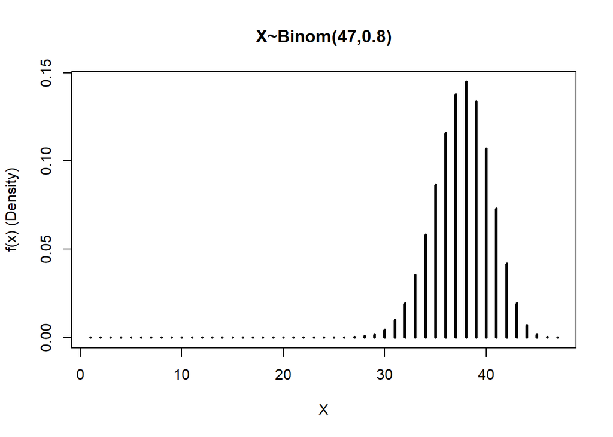

```r
n <- 47
theta <- 0.8
X <- 1:n
fX <- dbinom(X,n,theta)
plot(X, fX, type = 'h', lwd = 3, main = 'X~Binom(47,0.8)', xlab = 'X', ylab = 'f(x) (Density)')
```

2. What is the expected value of a Binomial(n=47, θ = 0.8) random variable?

```r
n*theta
```

```
## [1] 37.6
```

3. What is the standard deviation of a Binomial(n = 47, θ = 0.8) random variable?

```r
sqrt(n*theta*(1-theta))
```

```
## [1] 2.742262
```

4. Following are data from a clinical trial involving chemotherapy for testicular cancer. It is considered a success if a patient survived five years past the clinical trial. 3 subjects survived for five years past the trial, while 8 did not. What is the value of the (binomial) likelihood that 3 successes occur in 11 trials if θ (the probability of survival) is 0.5?

```r
dbinom(3,11,.5)
```

```
## [1] 0.08056641
```

5. Refer to question 4. What is the value of the likelihood if θ is 0.31?

```r
dbinom(3,11,.31)
```

```
## [1] 0.2525584
```

6. Refer to question 4. What is the value of the likelihood if θ is 0.27?

```r
dbinom(3,11,.27)
```

```
## [1] 0.2619136
```

7. Refer to question 4. Justify why you cannot find a value for θ that makes the likelihood larger than when θ = 3/11.

The MLE of a binomial is
$$\hat{p} =\frac{x}{n}$$

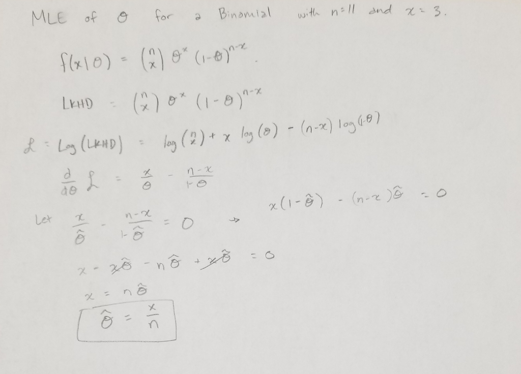

MLE Proof

8. Plot a beta(3, 5) pdf and a beta(5, 11) pdf on the same graph; the beta(3,5) should be in black and the beta(5,11) in gray. Also, be sure to properly format this graphic (x- and y-axes, overall title, and a legend).

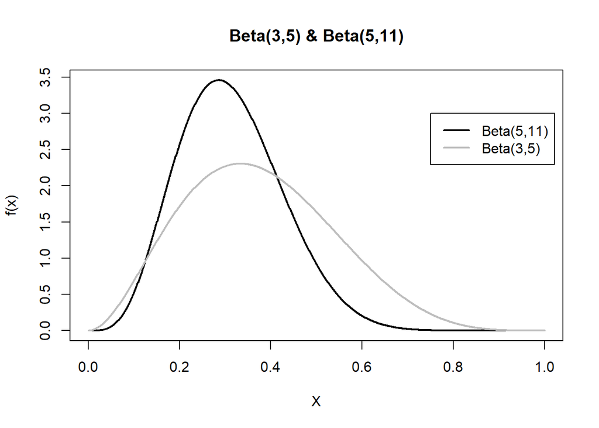

```r
X <- seq(0,1,length.out=1001)
plot(X,dbeta(X,shape1 = 5, shape2 = 11),
     col = 'black', lwd = 2, type = 'l',
     main = 'Beta(3,5) & Beta(5,11)',
     xlab = 'X',
     ylab = 'f(x)')
lines(X,dbeta(X, shape1 = 3, shape2 = 5),
      col = 'gray', lwd = 2)
legend(.75, 3, legend=c("Beta(5,11)", "Beta(3,5)"),
       col=c("black", "gray"), lty = 1, lwd = 2, cex = 1)
```

9. What is the height of the curve of a beta (1, 8) distribution at x = .24? That is, what is the pdf evaluated at x=.24?

```r
dbeta(.24, shape1 = 1, shape2 = 8)
```

```
## [1] 1.171616
```

10. What is the probability a beta (1, 8) random variable is less than 0.13?

```r
pbeta(.13, shape1 = 1, shape2 = 8)
```

```
## [1] 0.6717883
```

11. What is the probability a beta (3, 9) random variable is greater than .4?

```r
1 - pbeta(.4, shape1 = 3, shape2 = 9)
```

```
## [1] 0.1189168
```

12. What is the probability a beta (18,4.4) random variable is between 0.6 and 0.7?

```r
pbeta(.7,shape1 = 18, shape2 = 4.4) - pbeta(.6,shape1 = 18, shape2 = 4.4)
```

```
## [1] 0.09770375
```

13. At what value of x is the probability that a beta (4, 7) random varable is less than x equal to .71? That is, for what x is $\Pr(beta(4, 7) < x) = .71$?

```r
qbeta(.71, shape1 = 4, shape2 = 7)
```

```
## [1] 0.438946
```

14. At what value of x is the probability that a beta (12.2, 25.7) random variable is less than x equal to .2? That is, for what x is $\Pr(beta(12.2, 25.7) < x) = .2$?

```r
qbeta(.2, shape1 = 12.2, shape2 = 25.7)
```

```
## [1] 0.2572049
```

15. What is the expected value of a beta (3.1,4.8) random variable?

```r
a <- 3.1
b <- 4.8
a / (a+b)
```

```
## [1] 0.3924051
```

16. What is the variance of a beta (3, 5) random variable?

```r
a <- 3
b <- 5
(a*b) / (((a+b)**2) * ((a+b+1)))
```

```
## [1] 0.02604167
```

17. What is the mode of a beta(2.8, 2.1) random variable?

```r
a <- 2.8
b <- 2.1
(a−1) / (a+b−2)
```

```
## [1] 0.6206897
```

18. Show that the mode of a beta(a,b) random variable is $\frac{(a−1)}{(a+b−2)}$ when a > 1 and a + b > 2.

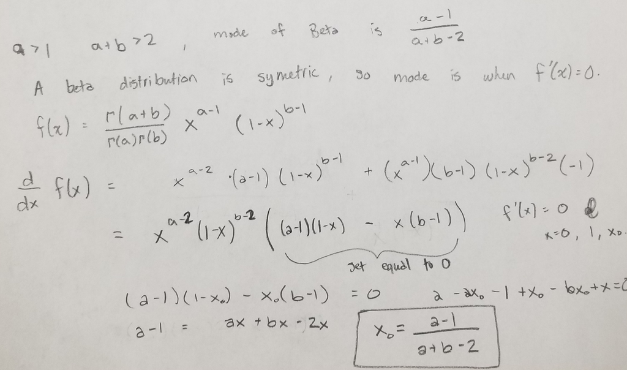

    Mode Proof

19. Refer again to question 4. In general terms, what is the posterior distribution for θ given the results of the clinical trial described in question 4 and assuming a beta(a,b) prior distribution for θ.
    $$\theta(a,b | y) \sim Beta(a+3, b+8)$$
20. Refer again to question 4. For this problem and assuming a beta(a,b) prior, what is
    $$\int_0^1 f(y|θ)π(θ)~dθ$$

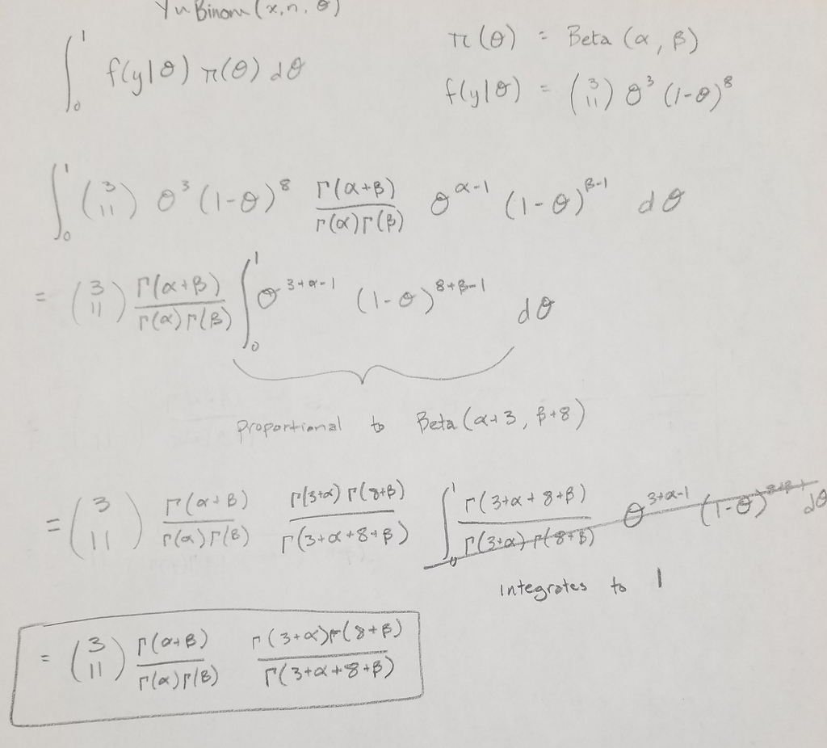

    Conditional * Prior

21. Refer again to question 4. Create one figure with two plots (i.e., use par(mfrow=c(1,2))). Each plot will contain two curves, a red one representing the prior distribution of θ and a blue representing the posterior distribution of θ. For the left plot, use a beta(1,1) prior distribution. Comment on what this prior distribution implies regarding prior beliefs of the analyst and the impact it has on the posterior. For the right plot, use a beta(25,1) prior distribution. Comment on what this prior distribution implies regarding prior beliefs of the analyst and the impact it has on the posterior.

[figure not shown]

```r
par(mfrow=c(1,2))
x <- 3
n <- 11
X <- seq(0,1,length.out=1001)
prior1 <- dbeta(X,shape1=1,shape2=1)
post1 <- dbeta(X,shape1=1+x, shape2=1+n-x)
plot(X,post1,
     col = 'blue', lwd = 2, type = 'l',
     main = 'Plot 1: Prior Belief Beta(1,1)',
     xlab = expression(theta),
     ylab = 'density')
lines(X,prior1,
      col = 'red', lwd = 2)
legend(.4, 3.15, legend=c("Prior", "Posterior"),
       col=c("red", "blue"), lty = 1, lwd = 2, cex = 1)

prior2 <- dbeta(X,shape1=25,shape2=1)
post2 <- dbeta(X,shape1=25+x, shape2=1+n-x)
plot(X,prior2,
     col = 'blue', lwd = 2, type = 'l',
     main = 'Plot 2: Prior Belief Beta(25,1)',
     xlab = expression(theta),
     ylab = 'density')
lines(X,post2,
      col = 'red', lwd = 2)
legend(0, 25, legend=c("Prior", "Posterior"),
       col=c("red", "blue"), lty = 1, lwd = 2, cex = 1)
```

For plot 1, the analyst has no prior inclination as to what the parameters are, so they assign a uniform distribution as the prior belief. This does not really impact the posterior that much.

For plot 2, the analyst has a strong prior belief that $theta$ is very close to 1. This heavily influences the posterior, so while the posterior mitigates that prior belief, the posterior distibution does not match our MLE.